# Analysing East / West Correlation within Covid

# Recreating the analysis

To ensure a fair comparison, it is important we first recreate the analysis. As no methodology was published, we are going to try and get as much information out of the tweets as possible. I provide all my processing within [GitHub](https://github.com/dr-harper/covid-correlation/blob/main/R/analysis.Rmd) for others to review, so please feel free to look if you want to understand more. If the assumptions are wrong, they can be tweaked.

## Data Sources

Two data sources were provided:

## Summary Map

Okay, the article starts with a summary of the deaths in Winter and Spring. This recreation is shown in Figure 1. The colour scale is a bit off, but you can see the point! I’ve include the whole of Europe for arguments sake.

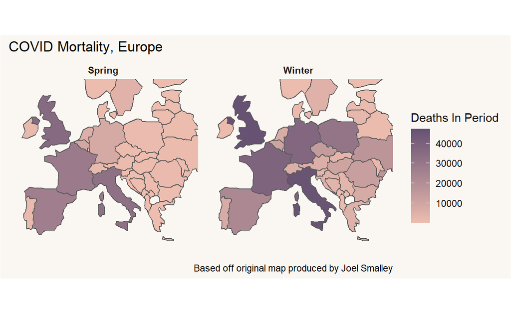

Figure 1: Map comparing Spring and Winter Covid Deaths, reproduced based on Joel Smalley’s work

I am not entirely sure what point this map is trying to prove, but it does demonstrate there are countries in Eastern Europe which were relatively minimal impact in Spring while are more so in Winter. Many countries in Western Europe seem to have had two spikes (i.e. United Kingdom).

## Time Plots

Again, we can recreate the plots in Figure 2. Before we jump into the grouping, I am going to present them as a single list with no categories. It is useful to make a quick comparison yourself to see whether you notice there are any potential similarities in the dataset. **If you are extra keen, try separating these into your own groups of similar style lines.** To prevent you having any bias, I have removed any labels for the country names so all you can use is the data.

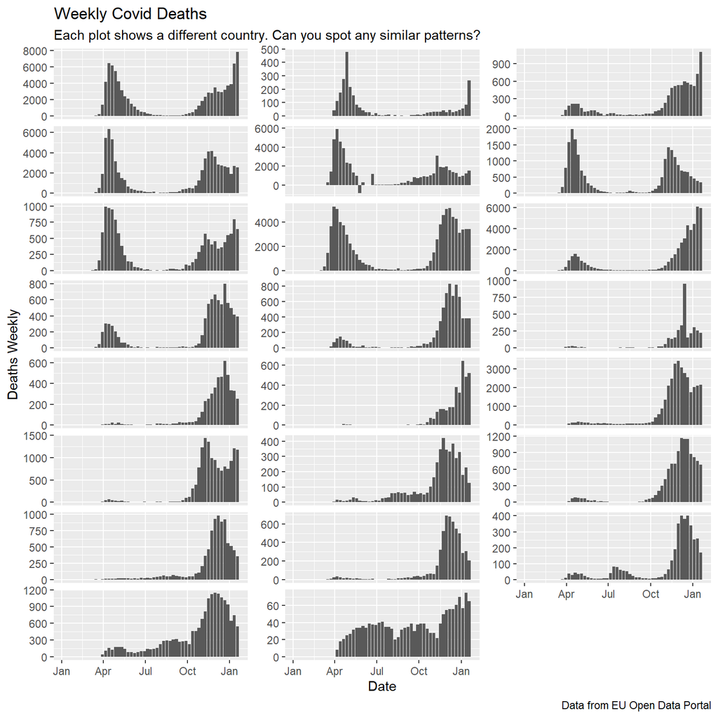

Okay, have you had a try at labelling them? Having had a look without any splitting, we can now plot these as grouped by Joel as shown in Figure 3. To help with Joel’s point, we can also visualise these trends on a map in Figure 4.

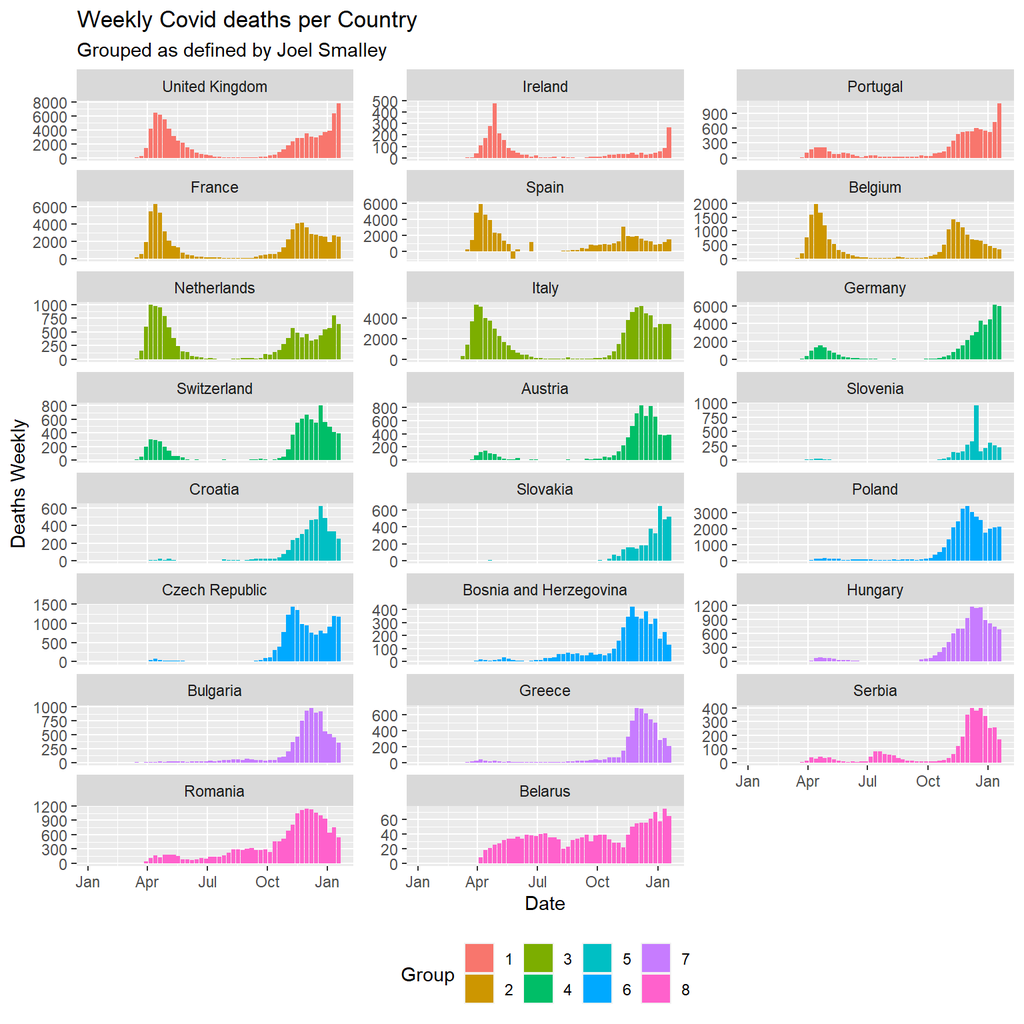

Figure 3: Weekly Covid Deaths, including labelling provided by Joel

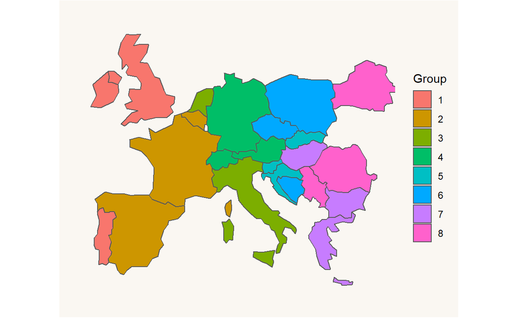

Figure 4: Map showing the grouping assigned by Joel

So, how would I review this clustering by Joel?

- Looking at the graph, you can clearly see similar patterns between countries that are grouped. Broadly these are defined by whether they have a peak in Spring, and the severity of the increase now
- There are some clear exceptions to the rules. For example, Portugal has been put into the same category as the UK and Ireland, although there was clearly a smaller first wave.
- By looking at the map, we can notice that the clustering is not purely on a E/W divide. Hungary has been grouped with Greece and Bulgaria.
- Also, regions with similar patterns do not necessarily border each other: for example the Netherlands and Italy.

It is really important to say that this provides empirical evidence of something interesting, but in the format presented by Joel, it cannot be used to assert the claims made. The grouping appears done by manual classification, and no numerical justification provided beyond the graphs, so we cannot directly correlate in this format that East/West has an impact. But is there any way we might be able to explore this concept further? We can explore that further below:

# Exploring East/West Correlation

Okay, so hopefully all of the work so far has made sense! As mentioned above, the above work from Joel provided a useful framing of the problem, but did not statistically prove a relationship from East to West. This section will explore this and try and understand if there is correlation.

There are many statistical models available, but a good approach for this kind of question is to use a clustering analysis. As explained [here](https://cran.r-project.org/web/packages/dtwclust/vignettes/dtwclust.pdf):

> Cluster analysis is a task which concerns itself with the creation of groups of objects, where each group is called a cluster. Ideally, all members of the same cluster are similar to each other, but are as dissimilar as possible from objects in a different cluster

So in this case, we are wanting to compare the pattern of the Covid-19 deaths for each of the countries and to join them together. Essentially, we are doing exactly what Joel did above, but removing any opportunity for subjectivity.

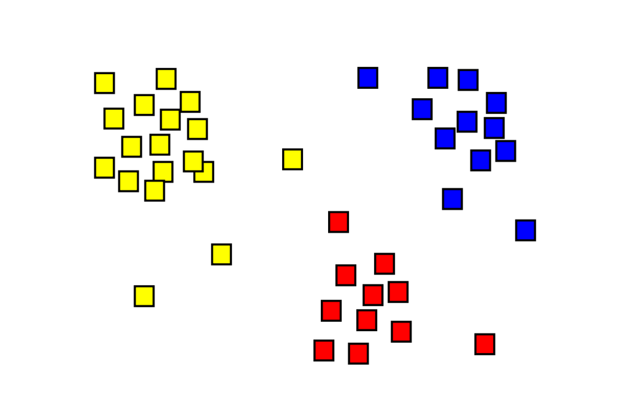

To start with I chose the same number of groups provided by Joel (8). The output of the clustering approach is shown in Figure 5. The dashed line shows the mean value of all lines which have been put together in each group, and we can see there are a few different types of patterns occuring.

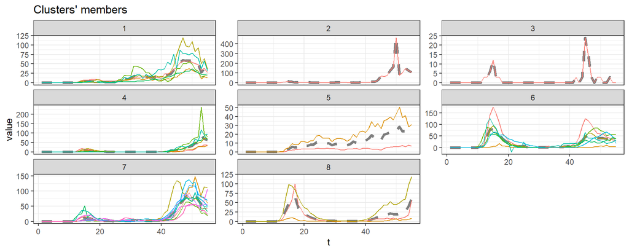

Figure 5: Output from clustering algorithm, 8 clusters specified

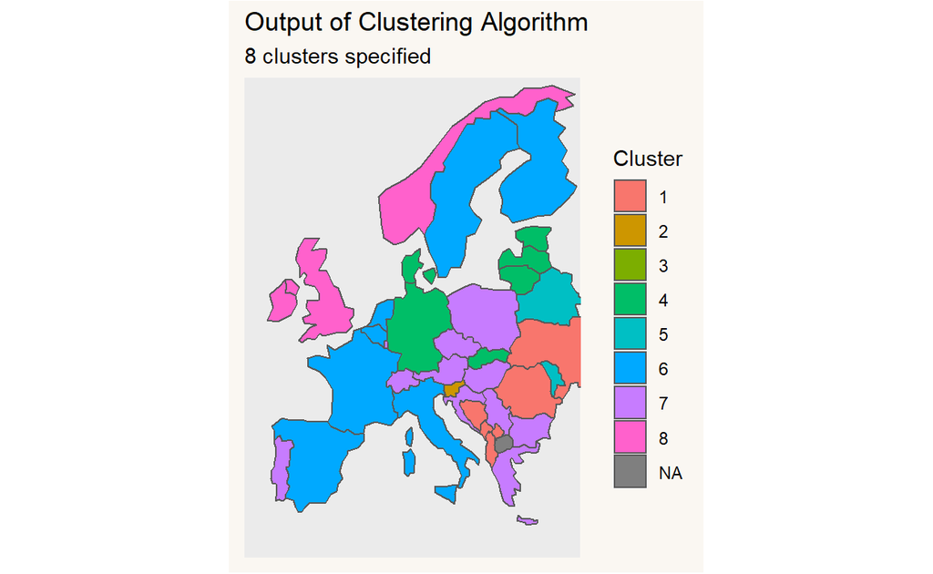

Figure 6: Map of results for clustering

After some exploring the cluster size, I decided it would be better to cut it down from 8. As you can see from the plot above, it is hard to tell the difference between each group, and therefore risked making it more confusing. Figure 7 shows the results with 4 clusters.

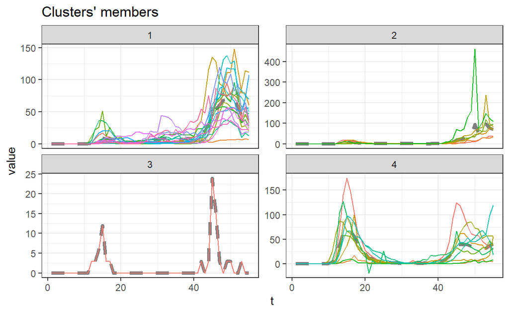

Figure 7: Graph showing output of clustering with 4 clusters

We can show this on the map again in Figure 8. So it would appear there are some regional relationships in the data, although i would caveat the above analysis is fairly lightweight. If I wanted to get this work published in a paper, I would have to do a lot more proof of the relationships, but hey ho, I wrote this analysis quickly over the weekend to get it online before too long.

Regarding the results, this has pulled some notably outliers. Portugal for example stands out as a country in Western Europe for having low spring deaths. Countries which appeared to have controlled the virus up until winter (group 2) are more dispersed than other groups.

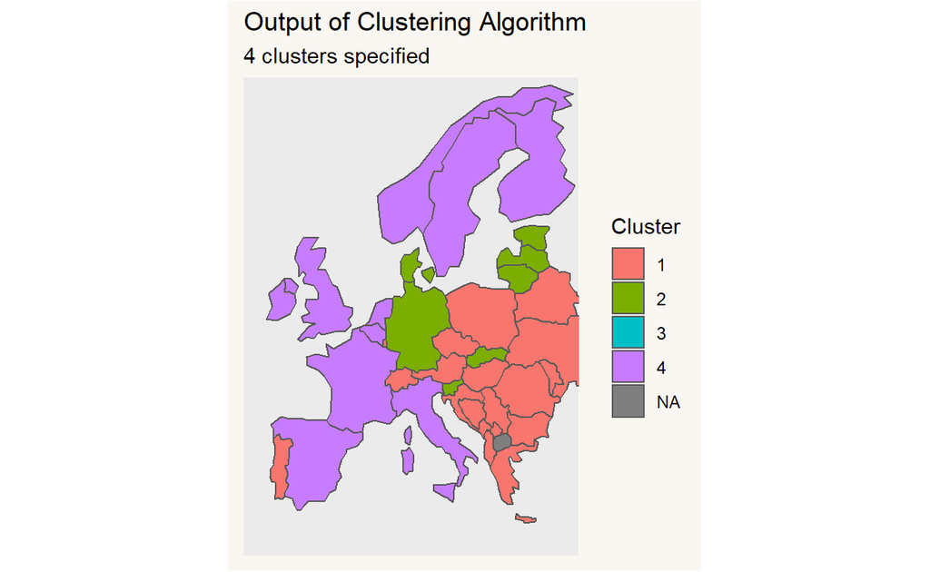

Figure 8: Map of results for clustering

Note, there are more ways we could explore the correlation, and the above results are by no means fully rigorous. Potentially, we could look at the total number of deaths encountered during spring and winter, and correlate these against longitude to see if there is a relationship. I purposely did not do any other approaches, as I wanted the analysis to remain as true to the original work as Joel. I would be happy to explore further if required.

# So what causes this relationship?

Having established there do appear to be some patterns in the data, we can now explore a bit what might be causing this. Again, to be faithful to the original analysis of Joel, my attention here is focussed to the Stringency Index data provided. As explained at the start, this gives us an indication of the level of restrictions introduced.

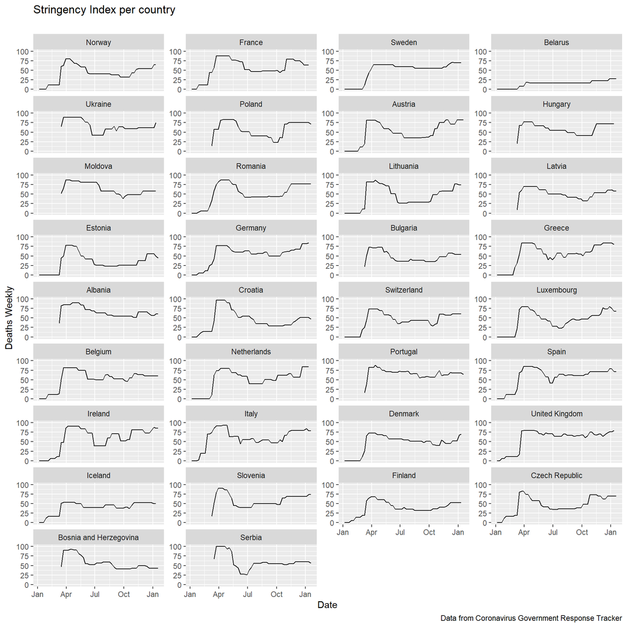

As with this clustering, there is often a simpler explanation behind things. What is notable is that countries which are grouped exhibited very different behaviours in the original lockdown. Notably, those in Group 4 from eaarlier were typically slower to ramp up the Stringency of lockdowns. The plot below shows the number of deaths which had been occured by the time the Stringency Index had been icnreased to 70.

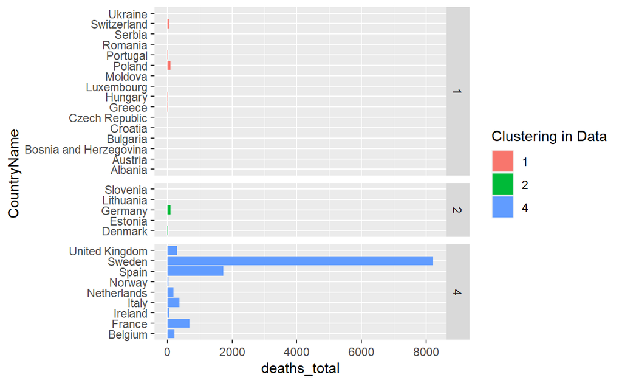

# Limitations of this work

This work is by no means conclusive. It was primarily designed as a response to the original work from Joel. I would however recommend:

- **More subnational statistics**: viewing relationships at a national level is convenient for the availability of data, but it really doesn’t capture the lower level patterns which are important in such analysis.
- **Considerations of climate**: there were claims within the comments that climate may be a cause of the patterns witnessed. Although literature suggests that this will only have a minimal impact on Covid, it was decided not to include it within this study.

Regarding climate, some literature already seems to suggest this isn’t a key factor: https://journals.plos.org/plosone/article?id=10.1371/journal.pone.0238339